# Part1 概率论和数理统计

### Alex Fang（Tsinghua University）

### 信息科学与技术学部，Alex.holla@foxmail.com

**摘要: ** 首先感谢来自深圳大学的几位同学的先前工作，part1的笔记是在他们的工作的基础上整理而成。按照**教材《概率论和数理统计》（同济版）**的排布，安排六个章节对主要知识点进行总结归纳。分别是：**基本名词**；**分布函数简介**；**二维分布函数**；**大数定律和中心极限定理**；**样本及抽样分布律**；**使用Numpy进行实践**。这份笔记中，主要选取与数理统计相关的内容进行整理，关于书中涉及的可视化技巧和Python编程技巧等，在这次笔记中不做赘述，欢迎查阅后续《Python语言与科学计算》和《可视化技巧梳理》的专题，如果对于统计学知识以及Python的numpy、pandas、scipy都已经比较了解了的话，建议直接阅读第三部分的笔记《可视化技巧梳理》。

**关键字：**数理统计；概率论；基于Python的数据分析

## 第一章 基本名词

$\begin{cases} 随机试验\\ 样本空间与随机事件\\ 频率与概率\\ 古典概型\\ 条件概率\\ \end{cases}$

概率论是一门研究事情发生的可能性的学问，但是最初概率论的起源与赌博问题有关。16世纪，意大利的学者吉罗拉莫·卡尔达诺（Girolamo Cardano）开始研究掷骰子等赌博中的一些简单问题。曾有一位MIT的老师问过我，如果说你只能记得一种数据分布，你会选择记住哪一种数据分布？我第一次回答的是，小孩子才做选择，而我全都要。第二次我正经了一些，我回答道，我想记住伯努利分布，因为他和金融相关性要大一些，毕竟对股票的涨、跌、不涨不跌的判断和掷骰子其实是同一回事（买股票有买股票的IC,赌场有赌场的IC，但事件的表现形式是十分相近的）。当然，我身边那些准备做深度学习的同学都是回答高斯分布的。

自然界和社会上发生的现象是多种多样的，有一类现象，在一定条件下必然发生，例如，向上抛一个石子必然下落，同性电荷必相互排斥，等等。这类现象称为**确定性现象**。在自然界和社会上还存在着另一类现象，例如，在相同条件下抛同一枚硬币，其结果可能是正面朝上，也可能是反面朝上。人们在经过长期时间并深入研究之后，发现这类现象在大量重复试验或观察下，它的结果却呈现出某种规律性，这种在大量重复试验或观察中所呈现的固有规律性，就是我们以后所说的**统计规律性**。

这种在个别试验中其结果呈现出不确定性，在大量重复试验中其结果又具有统计规律性的现象，我们称之为**随机现象**。概率论与数理统计是研究和揭示随机现象统计规律性的一门数学学科。

## $\S1.1$ 随机试验

我们遇到过各种试验，例如抛一枚硬币，观察正面$H$、反面$T$出现的情况。在这个试验中有两种可能结果，出现$H$或者出现$T$，但在抛掷之前不能出现$H$还是出现$T$，这个试验可以在相同的条件下重复地进行。概括这一类试验具有以下几个特点：

- 可以在相同的条件下重复地进行；
- 每次试验的可能结果不止一个，并且能事先明确试验的所有可能的结果；
- 进行一次试验之前不能确定哪一个结果会出现。

在概率论中，我们将具有上述三个特点的试验称为**随机试验**。

## $\S1.2$ 样本空间、随机事件

### （一）样本空间

对于随机试验，尽管我们不能预知试验的结果，但试验的所有可能结果组成的集合是已知的。我们将随机试验$E$的所有结果组成的集合成为$E$的**样本空间**,记为$S$。样本空间的元素，即$E$的每个结果，称为**样本点**。
例如，1中的试验$E_{抛硬币}$的样本空间$S_{抛硬币}$：$$S_{抛硬币}=\{H、T\}$$其中样本点为正面$H$,反面$T$。

### （二）随机事件

一般，我们称试验$E$的样本空间$S$的子集为$E$的**随机事件**，简称为**事件**。在每次试验中，当且仅当这一子集中的一个样本点出现时，称为一**事件发生**。特别的，由一个样本点组成的单点集，称为**基本事件**，例如抛硬币中的两个基本事件为$\{T\}和\{H\}$。  
样本空间$S$包含所有的样本点，它是$S$自身的子集，在每次试验中它总是发生的，$S$称为**必然事件**。空集$\emptyset$不包含任何样本点，它作为样本空间的子集，他在每次试验中都不发生，$\emptyset$称为**不可能事件**。

### （三）事件间的关系与事件的运算

设试验$E$的样本空间为$S$,而$A、B、A_k(k=1,2,...)$是$S$的子集。

- 若$A\subset B$，则称事件$B$包含事件$A$，这指的是事件$A$发生必导致事件$B$发生。若$A\subset B且B\subset A$,则称事件$A$与时间$B$**相等**。
- 事件$A\cup B={x|x\in A 或x\in B}$称为事件$A$与事件$B$的**和事件**，当且仅当$A$、$B$中至少有一个发生时，事件$A\cup B$发生。  
  类似地，称$\bigcup\limits_{k=1}^{n}A_k$为$n$个事件$A_1,A_2,...,A_n$的和事件；
- 事件$A\cap B=\{x|x\in A 且x\in B\}$称为事件$A$与事件$B$的**积事件**。当且仅当$A、B$同时发生时，事件$A\cap B$发生，$A\cap B$也记作$AB$。 类似地，称$\bigcap\limits_{k=1}^{n}A_k$为$n$个事件$A_1,A_2,...,A_n$的积事件；
- 事件$A-B={x|x\in A且x\in B}$称为事件$A$和事件$B$的**差事件**。当且仅当$A$发生、$B$不发生事件$A-B$发生。
- 若$A\cap B=\emptyset$，则称事件$A$与$B$是**互不相容**的，或**互斥**的。这指的是事件$A$与事件$B$不能同时发生。基本事件是两两互不相容的。
- 若$A\cup B=S且A\cap B=\emptyset$，则称事件$A$与事件$B$互为**逆事件**，又称事件$A$与事件$B$互为**对立事件**。这指的是对每次试验而言，事件$A$、$B$中必有一个发生，且仅有一个发生。$A$的对立事件记为$\overline A$。$\overline A=S-A$。

在进行事件运算时，经常要用到下述定律，设$A,B,C$为事件，则有  
1. 交换律：$A\cup B=B\cup A;A\cap B=B\cap A$.  
2. 结合律：$A\cup(B\cup C)=(A\cup B)\cup C$ ; $A\cap (B\cap C)=(A\cap B)\cap C$.  
3. 分配律：$A\cup(B\cap C)=(A\cup B)\cap(A\cup C)$ ; $A\cap(B\cup C)=(A\cap B)\cup(A\cap C)$.  
4. 德摩根律：$\overline{A\cup B}=\overline A\cap \overline B$ ; $\overline{A\cap B}=\overline A\cup \overline B$

#### 例题：</font>

设将一枚硬币抛掷三次为$E$事件，其中$A_1$：“第一次出现的是$H$”,即

$$A_1=\{HHH,HHT,HTH,HTT\}$$事件$A_2$:“三次出现同一面”，即

$$A_2=\{HHH,TTT\}$$则有：$$A_1\cup A_2=\{HHH、HHT、HTH、HTT、TTT\}$$

$$A_1\cap A_2=\{HHH\}$$

$$A_2-A_1=\{TTT\}$$

$$\overline{A_1\cup A_2}=\{THT、TTH、THH\}$$

## $\S1.3$ 频率与概率

### （一）频率

**定义**：在相同的条件下，进行了n次试验，在这n次试验中，事件A发生的次数 ，称为事件A发生的频数，比值$n_A$/$n$称为事件A发生的频率，并记成 $f_n(A)$。则有 ：

$$f_n(A)=\frac{n_A}{n}$$
有定义，可见频率具有下述基本性质：

- $0\le f_(A)\le 1$;
- $f_n(S)=1$;
- 若$A_1,A_2,...,A_k$是两两互不相容的事件，则

$$f_n(A_1\cup A_2\cup ...\cup A_k)=f_n(A_1)+f_n(A_2)+...+f_n(A_k)$$。

#### 例题：</font>

你从一副扑克牌中抽一张牌，抽到A的频率有多大？ $$P(抽到A)=\frac{一副牌中A的数量}{一副牌中所有牌的数量}=\frac{4}{52}=0.769$$

#### 例题：</font>

```
0 5
120.0 -856.0
```

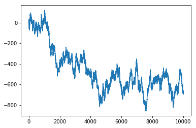

```python
import numpy as np#导入画图模块
from matplotlib.pyplot import plot,show#导入matplotlib模块的画图和显示函数
money=np.zeros(10000)#先将赌博次数的每一次的money初始化为0money[0]=1000#表示刚开始有1000元现金
result=np.random.binomial(5,0.5,size=len(money))#二项分布的10000次成功的次数
#遍历10000数，更新每一次的moeny值存储
for i in range(1,len(money)):#从1到10000进行遍历
    if result[i]<3:
        money[i]=money[i-1]-8
    else:
        money[i]=money[i-1]+8
print(result.min(),result.max())#打印5次抛硬币最多出现正面，和最少出现正面的次数
print(money.max(),money.min())#打印可能出现钱最多，最少的情况
plot(np.arange(len(money)),money)#画图show()#显示输出结果：
```

### （二）概率

**定义**设$E$是随机试验，$S$是它的样本空间，对于$E$的每一个事件$A$赋予一个实数，记为$P(A)$,称为事件$A$的**概率**，则有

$$ P(A)=\lim_{n_t}\frac{n_A}{n_t}$$
如果集合函数$P$满足下列条件：

- **非负性**：对于每一个事件$A$,有$P(A)\ge0$;
- **规范性**：对于必然事件$S$,有$P(S)=1$;
- **可列可加性**： 设$A_1,A_2,...$是两两互不相容的事件，即对于$A_iA_j=\emptyset,i\ne j,i,j=1,2,...$，有

$$P(A_1\cup A_2\cup...)=P(A_1)+P(A_2)+...$$ 由概率的定义，可以推出概率的一些重要性质：

#### 性质1 **$P(\emptyset=0)$**

证： 令$A_n=\emptyset(n=1,2,...)$,则$\bigcup\limits_{n=1}^{\infty}A_n=\emptyset$，且$A_iA_j=\emptyset,i\ne j,i,j=1,2,...$,由概率的可列可加性得：

$$P(\emptyset)=p(\bigcup\limits_{n=1}^{\infty}A_n)=\sum_{i=1}^{n} P(A_n)=\sum_{i=1}^{n} P(\emptyset)$$ 由概率的非负性知,$P(\emptyset)\ge 0$，故由上式知$P(\emptyset)=0$

#### 性质2 有限可加性：若$A_1,A_2,...,A_n$是两个互不相容的事件，则有

$$P(A_1\cup A_2\cup...\cup A_n)=P(A_1)+P(A_2)+...+P(A_n)$$ 证：令$A_{n+1}=A_{n+2}=...=\emptyset$，即有$A_iA_j=\emptyset,i\ne j,i,j=1,2,...$,由可列可加性有

$P(A_1\cup A_2\cup...\cup A_n)\\=P(\bigcup\limits_{n=1}^{\infty}A_n)=\sum_{i=1}^{n}P(A_i)\\=\sum_{i=1}^{n}P(A_i)+0=P(A_1)+P(A_2)+...+P(A_n)$

#### 性质3.设A,B是两个事件，若$A\in B$ ，则有

$$P(B-A)=P(A)-P(B)\\P(B)\ge P(A)$$ 证：由$A\in B$知$B=A\cup(B-A)$,且$A(B-A)=\emptyset$,再由有限可加性得，

$$P(B)=P(A)+P(B-A)$$,在由概率的非负性，$P(B-A)\ge 0$

$$P(B)\ge P(A)$$。

#### 性质4.对于任一事件A，$$P(A)≤1$$

证：因$A\in S$，有上面的性质得

$$P(A)\le P(S)=1$$

#### 性质5.对于任一事件A，有 $$P(\bar{A})=1-P(A)$$

证 因$A\cup\bar{A}=S$,且$A\bar{A}=\emptyset$，得

$$1=P(S)=P(A\cup\bar{A})=P(A)+P(\bar{A})$$

#### 性质6.对于任意两事件A,B有

$$P(A\cup B)=P(A)+P(B)-P(AB)$$ 证：因$A\cup B=A\cup(B-AB)$，且$A(B-AB)=\emptyset,AB\in B$,得

$P(A\cup B)=P(A)+P(B-AB)\\=P(A)+P(B)-P(AB)$

推广到多个事件的情况，例如，设$A_1,A_2,A_3,...,A_n$为n个事件，则可以用归纳法有

$$ P(A_1\cup A_2\cup …\cup A_n ）=\sum_{i=1}^{n}P(A_i) -\sum_{1\le i<j\le n}P(A_iA_j)\\+\sum_{1\le i<j<k\le n}P(A_iA_j) +…+(-1)^(n-1)P(A_1A_2...A_n)$$

## $\S1.4$ 等可能概型（古典概型）

**定义** 具有以下两个特点的试验称为等可能概型：
1.试验的样本空间只包含有限个元素
2.试验中每个基本事件发生的可能性相同
具有以上两个特点的试验是大量存在的，这种试验称为**等可能概型**，它在概率论发展初期曾是主要的研究对象，所以也称为**古典概型**。
下面我们来讨论等可能概型中事件概率的计算公式。 设试验的基本空间为$S=\{e_1,e_2,...,e_n\}$，由于在试验中每个基本事件发生的可能性相同，即有 $$P(\{e_1\}=P(\{e_2\}=...P(\{e_n\})$$ 又由于基本事件是两两互不相容的，于是

$$1=P(S)=P(\{e_1\}+P(\{e_2\}+...P(\{e_n\})\\=nP(\{e_i\})\\P(\{e_i=\frac{1}{n}\}),i=1,2,...,n$$ 即

$$P(A)=\sum_{i=1}^{k}P(\{e_i\})=\frac{k}{n}=\frac{A包含的基本事件数}{S中基本事件的总数}$$

#### 例题：</font>

将一枚硬币抛掷三次（1）设事件$A_1$为“恰有一次出现正面”，求$P(A_1)$;(2)设事件$A_2$为“至少有一次出现正面”，求$P（A_2)$

(1)$$P(A_1)=\frac{3}{8}$$ (2)$$P(A_2)=1-\overline P(A_2)=1-\frac{1}{8}=\frac{7}{8}$$ 人们在长期的实践中总结得到**“概率很小的事件在一次试验中实际上几乎是不发生的”**，称之为**实际推断原理**。

## $\S1.5$ 条件概率

### （一）条件概率

条件概率是概率论中的一个重要而实用的概念，所考虑的是事件A已发生的条件下事件B发生的概率。  
**定义** 设A，B是两个事件，且$P(A)>0$，称

$$P(B|A)=\frac{P(AB)}{P(A)}$$ 为在事件A发生的条件下事件B发生的**条件概率**。 由此定义可以得到条件概率P(•｜A)的性质：

- 非负性:$P(B｜A)≥0$;
- 规范性：对于必然事件S，有$P(S｜A)=1$
- 可列可加性：设$B_1,B_2…$是两两互不相容的事件，则有

$$P(\bigcup\limits_{i=1}^{\infty}B_i|A)=\sum_{i=1}^{\infty}P(B_i|A)$$

#### 例题：</font>

甲袋中有5只白球, 7 只红球;乙袋中有4只白球, 2只红球.从两个袋子中任取一袋, 然后从所取到的袋子中任取一球,求取到的球是白球的概率.
设事件A表示“取到的是甲袋”, 则 表示“取到的是乙袋”,事件B表示“最后取到的是白球”. 根据题意: $$P(B|A)=\frac{5}{12}\\P(B|\bar{A})=\frac{2}{3}\\P(A)=\frac{1}{2}\\P(B)=P(B|A)P(A)+P(B|\bar{A})P(\bar{A})\\=\frac{5}{12}*\frac{2}{3}*(1-\frac{1}{2})=\frac{13}{24}$$

### （二）乘法原理

由条件概率的定义，立即可得到下述定理: **乘法原理**：设$P(A)>0$，则有$$P(AB)=P(B｜A)P(A)$$

### （三）全概率公式和贝叶斯公式

**定义** ：设S为试验E的样本空间,$B_1,B_2,...,B_n$为E的一组事件，若

(1)$B_iB_j=\emptyset,i\ne j,i,j=1,2,...,n$;

(2)$B_1\cup B_2\cup …\cup B_n=S$;  
则称$B_1,B_2,...,B_n$为样本空间$S$的一个**划分**。

#### 例题：</font>

据美国的一份资料报导，在美国总的来说患肺癌的概率约为$0.1\%$，在人群中有$20\%$是吸烟者，他们患肺癌的概率约为$0.4\%$，求不吸烟者患肺癌的概率是多少？ 解：以C事件“患肺癌”，以A记事件“吸烟”，按题意$P(C)=0.001,P(A)=0.20,P(C|A)=0.004$,需要求条件概率$P(C|\bar{A})$，由全概率公式有$$P(C)=P(C|A)P(A)+P(c|\bar{A})$$将数据代入，得$$0.001=0.004*0.20+P(C|\bar{A})P(A)\\=0.004*0.20+P(C|\bar(A))*0.80\\P(C|\bar{A})=0.00025$$

#### 例题：</font>

三门问题（Monty Hall problem）亦称为蒙提霍尔问题、蒙特霍问题或蒙提霍尔悖论，大致出自美国的电视游戏节目Let's Make a Deal。问题名字来自该节目的主持人蒙提·霍尔（Monty Hall）。参赛者会看见三扇关闭了的门，其中一扇的后面有一辆汽车，选中后面有车的那扇门可赢得该汽车，另外两扇门后面则各藏有一只山羊。当参赛者选定了一扇门，但未去开启它的时候，节目主持人开启剩下两扇门的其中一扇，露出其中一只山羊。主持人其后会问参赛者要不要换另一扇仍然关上的门。问题是：换另一扇门会否增加参赛者赢得汽车的机率？

```python
from random import choice

def stay():
    doors = ['car','goat','goat']       #设置三扇门，其中两扇门后面是山羊，一扇门后是汽车
    choose = choice(doors)              #随机选择一扇门
    if choose == 'car':                 #不换门则直接判断
        return 'win'
    else:
        return 'lose'

def switch():
    doors = ['car', 'goat', 'goat']
    choose = choice(doors)
    doors.remove(choose)               #选择的门放一边
    doors.remove('goat')               #剩下的门，去掉一只山羊
    if doors == ['car']:               #换门
        return 'win'
    else:
        return 'lose'



if __name__ == '__main__':
    total = 100000
    count_switch = 0
    win_switch = 0
    count_stay = 0
    win_stay = 0
    for i in range(total):
        choose = choice([1,2])          #随机选择换门还是不换门
        if choose == 1:
            count_switch += 1
            if switch() == 'win':
                win_switch += 1
        else:
            count_stay += 1
            if stay() == 'win':
                win_stay += 1

    print('换门次数:',count_switch)
    print('换门后得到汽车:',win_switch,'%.2f%%'%(100*win_switch/count_switch))
    print('不换门:',count_stay)
    print('不换门后得到汽车:',win_stay,'%.2f%%'%(100*win_stay/count_stay))
```

```
换门次数: 49805
换门后得到汽车: 33222 66.70%
不换门: 50195
不换门后得到汽车: 16646 33.16%
```

## $\S1.6$ 独立性

**定义** ：设A、B是两事件，如果满足如下等式，则称事件A、B**相互独立**，简称A、B**独立**。容易得到，若$P(A)>0,P(B)>0$，则A，B互相独立与A，B互不相容不能同时成立。
$$P(AB)=P(A)P(B)$$

**定理一**： 设A,B是两事件，且P(A)>0，若A,B相互独立，则P(B｜A)=P(B),反之亦然。

**定理二**： 若事件A与B相互独立，则下列各对事件也相互独立：A与$\bar{B}$ , $\bar{A}$与B, $\bar{A}$与$\bar{B}$
**证** 因为$A=A(B\cup \bar{B})=AB\cup A\bar{B}$,得到$$P(A)=P(AB\cup A\bar{B})=P(AB)+P(A\bar{B})\\=P(A)P(B)+P(A\bar{B})\\P(A\bar{B})=P(A)[1-P(B)]=P(A)P(\bar{B})$$

**定义**设A,B,C是三个事件，如果满足等式如下，则称事件A,B,C相互独立。 $$P(AB)=P(A)P(B),\\P(BC)=P(B)P(C)\\P(AC)=P(A)P(C),\\P(ABC)=P(A)P(B)P(C)$$

**推论**：

1.若事件$A_1,A_2,...,A_n$(n≥2)相互独立，则其中任意k(2≤k≤n)个事件也是相互独立；

2.若n个事件 $A_1,A_2,...,A_n$(n≥2)相互独立，则将 … 中任意多个事件换成它们的对立事件，所得的n各事件仍相互独立

## 第二章 分布函数简介

$\begin{cases} 离散型随机变量和连续性随机变量的分布规律\\ 分布函数的性质\\ 八大常见的分布函数\\ 几种有具体应用场景的分布 \end{cases}$

## $\S2.1$ 离散型随机变量和连续型随机变量的分布规律

#### 离散型随机变量的分布规律

设离散型随机变量$X$的可能取值为$X_k$$(k=1,2,\ldots)$且取各个值的概率,即事件$(X=x_k)$的概率为: $$P(X=x_k)=p_k，k=1,2,…，$$
显然分布律应满足下列条件:
$1.p_k\geq0，k=1,2,…,n$

$2.\sum_{k=1}^\infty{p_k}=1$

#### 连续型随机变量的分布规律

设$F(x)$是随机变量$X$的分布函数，若存在非负函数$f(x)$，对任意实数，有$$F(x)=\int_{-\infty}^x{f(x)}{\rm d}x$$
则称$X$为连续型随机变量。$f(x)$称为$x$的概率密度函数或密度函数，简称**概率密度**。

**密度函数具有下面4个性质:**

$1.f(x)\geq 0$

$2.F(x)=\int_{-\infty}^{+\infty}{f(x)} \,{\rm d}x=1$

$3.对于任意实数x_1,x_2,(x_1<x_2),P(x_1\leq X\leq x_2)=F(x_2)-F(x_1)=\int_{x_1}{x_2}f(x)dx$

$4.若f(x)$在点$x$处连续，则有$F^{'}(x)= f(x)$

**非离散型随机变量的特点:**

1.其可能取值不能一个一个地列举出来

2.非离散型随机变量取任一指定的实数值的概率都等于0

3.在计算连续型随机变量落在某一区间的概率时，可以不必区分该区间是开区间或闭区间或半闭区间

##### 离散与连续型随机变量的关系

$$P(X=x)\approx P(x<X\leq x+dx)\approx f(x)dx$$

## $\S2.2$ 分布函数

设$X$为随机变量，是$x$任意实数，则函数$F(x)=P(X\leq x)$称为随机变量X的分布函数，本质上是一个累积函数。

$P(a<X\leq b)=F(b)-F(a)$ 可以得到X落入区间(a,b]的概率。分布函数F(x)表示随机变量落入区间$(-\infty，x]$内的概率。

**分布函数具有如下性质：**：

1.$0\leq F(x)\leq 1,-\infty<x<+\infty$

2.$F(x)$是单调不减的函数，即$x_1<x_2$时，有$F(x_1)\leq F(x_2)$

3.$F(+\infty)=\lim_{x \to +\infty}F(x)=1$

4.$F(x+0)=\lim_{\Delta x \to -\infty }F(x+\Delta x)=F(x)$, $F(x)$即是右连续的

5.$P(a<X\leq b)=p(X\leq b)-p(x\leq a)=F(b)-F(a)$

6.$P(X>a)=1-P(X\leq a)=1-F(a)$

7.$F(x)=\sum_{x_k\leq x}^{}P_k$

8.$F(x)=\int_{-\infty}^x f(x), F^{'}(x)=f(x)$

## $\S2.3$ 八大常见的分布函数

**八大分布** $\begin{cases} \;离散型随机变量分布\begin{cases} \;0-1分布\\ \;二项分布\\ \;泊松分布\\ \;超几何分布\\ \;几何分布\\ \end{cases}\\ \;连续型随机变量分布 \begin{cases} \;均匀分布\\ \;指数分布\\ \;正态分布\\ \end{cases} \end{cases}$

##### (1)0-1分布

| 随机变量X | 0 | 1 |
| --- | --- | --- |
| 概率P | $p$ | $q$ |

$$P(X=1)=p, P(X=0)=q$$

##### (2)二项分布

在$n$重贝努里试验中，设事件$A$发生的概率为$P$。事件$A$发生的次数是随机变量，设为$X$，则可能取值为$0,1,2,\ldots,n$。

二项分布的分布律为：$$P(X=k)=P_n(k)={C_n}^kp^kq^(n-k)$$
其中$q=1-p,0<p<1,k=0,1,2,\ldots,n$，则称随机变量$X$服从参数为$n$的二项分布,记为$X\sim B(n,p)$。

当$n=1$时$P(X=k)=p^kq^(1-k)$，这就是（0-1）分布，所以（0-1）分布是二项分布的特例。

##### (3)泊松分布

设随机变量的分布律为: $$P(X=k)=\frac{\lambda ^k}{k!}e^{-\lambda},\lambda>0,k=0,1,2\ldots$$

则称随机变量$X$服从参数为$\lambda$的泊松分布，记为$X\sim \pi(\lambda)$或者$P(\lambda)$。

泊松分布为二项分布的极限分布$(np=\lambda,n\to \infty)$。

##### (4)超几何分布

$$P(X=k)=\frac{C_M^k \cdot C_{N-M}^{n-k}}{C_N^n},k=0,1,2\ldots,l；l=min(M,n)$$

随机变量X服从参数为$n,N,M$的超几何分布，记为$X\sim H(n,N,M)$。

##### (5)几何分布

$$P(X=k)=q^{k-1}p,k=1,2,3,\ldots其中p\geq 0，q=1-p$$

随机变量$X$服从参数为$p$的几何分布，记为$G(p)$。

##### (6)均匀分布

设随机变量$X$的值只落在$[a,b]$内，其密度函数$f(x)$在$[a,b]$上为常数$\frac{1}{b-a}$，即：

$$f(x)=\begin{cases} \frac{1}{b-a},& a\leq x\leq b \\ 0,& 其它 \end{cases}$$

则称$X$随机变量在$[a,b]$上服从均匀分布，记为$X\sim U(a，b)$。

**分布函数**为： $$F(x)=\int_{-\infty}^{x}f(x)d(x)=\begin{cases} 0,& x<a\\ \frac{x-a}{b-a},& a\leq x\leq b\\ 1,& x>b \end{cases}$$
当$a\leq x_1<x_2\leq b $时，X落在区间$(x_1,x_2)$内的概率为$P(x_1<X<x_2)=\frac{x_2-x_1}{b-a}$

该随机变量X落在区间（a,b)中任意等长度的子区间内的可能性是相同的，或者说它落在（a,b)的子区间内的概率只依赖与子区间的长度而与子区间的位置无关。

##### (7)指数分布

$$f(x)=\begin{cases} \lambda e^{-\lambda x},&x\geq 0\\ 0,&x<0 \end{cases}$$

其中$\lambda$,则称随机变量$X$服从参数为$\lambda$的指数分布。

X的**分布函数**为 $$f(x)=\begin{cases} 1-e^{-\lambda x},&x>0 \\ 0,&x<0 \end{cases}$$
记住积分公式： $$\int_{0}^{+\infty}x^ne^{-x}dx=n!$$

服从指数分布的随机变量X具有以下性质：（无记忆性）

对于任意$s,t>0$,有$P(X>s+t\;|\;X>s)=P(X>t)$

证明:
$$P(X>s+t\;|\;X>s)=\frac{P{(X>s+t)\bigcap (X>s)}}{p(X>s)}=\frac{P(X>s+t)}{p(X>s)}=\frac{1-F(s+t)}{1-F(s)}=\frac{e^{-(s+t)/\theta}}{e^{-s/\theta}}=e^{-t/\theta}=1-F(t)=1-P(X\leq t)=p(X>t)$$

##### (8)正态分布

设随机变量$X$的**密度函数**为： $$f(x)=\frac{1}{\sqrt{2\pi\sigma}}e^{-\frac{(x-\mu)^2}{2\sigma^2}},-\infty<x<+\infty$$

其中$\mu,\sigma>0$为常数，则称随机变量$X$服从参数$\mu$,$\sigma$的正态分布或高斯（Gauss）分布，记为$X\sim N(\mu,\sigma^2)$。

$f(x)$**具有如下性质**：

1.$f(x)$的图形是关于$x=\mu$对称的,对于任意$h>0$有$P\mu-h<X\leq\mu)=P(\mu<X\leq\mu+h)$

2.当$x=\mu$时，$f(\mu)=\frac{1}{\sqrt{2\pi\sigma}}$为最大值。

$X$离$\mu$越远，$f(x)$的值越小，这表明对于同样长度的区间，当区间离$\mu$越远，$X$落在这个区间上的概率越小

$f(x)$**的形状特性**：

1.固定$\sigma$，改变$\mu$的值，则图形沿着$Ox$轴平移，而不改变其形状，可见正态分布函数的概率密度曲线$y=f(x)$的位置完全由参数$\mu$所确定，称$\mu$为位置参数;

2.固定$\mu$，改变$\sigma$的值，由于最大值,可知当$\sigma$越小图形变得越尖，因而$X$落在$\mu$附近概率越大;

若$X~N(\mu,\sigma^2)$则$X$的**分布函数**为： $$F(x)=\frac{1}{\sqrt{2\pi\sigma}}\int_{-\infty}^{x}e^{-\frac{(t-\mu)^2}{2\sigma^2}}dt$$

参数$\mu=0,\sigma=1$时的正态分布称为标准正态分布，记为$X~N(0,1)$。

**其密度函数记为**： $$\phi(x)=\frac{1}{\sqrt{2\pi}}e^{-\frac{x^2}{2}},-\infty <x< +\infty$$

**分布函数为**： $$\Phi(x)=\frac{1}{\sqrt{2\pi}}\int_{-\infty}^{x}e^{-\frac{t^2}{2}}dt$$

$\Phi(x)$是不可求积函数，其函数值，已编制成表可供查用。 $\phi(x)$**具有如下性质**：

1.$\Phi(1-x)=1-\Phi(x)$且$\Phi(0)=\frac{1}{2}$；

2.如果$X~N(\mu,\sigma^2)$,则$\frac{X-\mu}{\sigma}~N(0,1)$；

3.$P(x_1<X\leq x_2)=\Phi(\frac{x_2-\mu}{\sigma})-\Phi(\frac{x_1-\mu}{\sigma})$。

##### 分位数介绍

下分位表：$P(X\leq \mu_\alpha)=\alpha$；

上分位表：$P(X\geq \mu_\alpha)=\alpha$。

##### 超几何、二项、泊松分布之间的近似关系

定理(泊松定理) 在$n$重伯努利试验中, 事件$A$在每次试验中发生的概率为$p_n$(注意这与试验次数$n$有关), 如果$n\to \infty$时,$np_n \to \lambda$($\lambda$>0为常数).则对于任意给定的k,有 $$\lim_{n \to \infty}B(k,n,p_n)=lim_{n \to \infty}C_n^kP_n^k(1-p_n)^{n-k}=\frac{{\lambda}^k}{k!}e^{-\lambda}$$

定理 :超几何分布的极限分布是二项分布
即:在超几何分布中对于固定的$n,k$，如果 $$lim_{N \to +\infty}\frac{M}{N}=p $$ 则有极限关系： $$lim_{N \to +\infty}\frac{C_M^kC_{N-M}^{n-k}}{C_N^n}=C_n^kp^k(1-p)^n-k $$

对所有的$0\leq k\leq n$都成立。

##### 八大分布规律及其性质总览

| 分布 | 参数 | 分布律或概率密度 | 数学期望 | 方差 |
| --- | --- | --- | --- | --- |
| (0-1)分布 | $0<p<1$ | $P(X=1)=p, P(X=0)=q$ | $p$ | $p(1−p)$ |
| 二项分布 | $n≥1,0<p<1$ | $P(X=k)=P_n(k)={C_n}^kp^kq^(n-k)$ | $np$ | $np(1−p)$ |
| 几何分布 | $0<p<1$ | $P(X=k)=q^{k-1}p,其中q=1-p$ | $\frac{1}{p}$ | $\frac{1-p}{p^2}$ |
| 泊松分布 | $λ>0$ | $P(X=k)=\frac{\lambda ^k}{k!}e^{-\lambda}$ | $λ$ | $λ$ |
| 超几何分布 | $M,N,n>0$ | $P(X=k)=\frac{C_M^k \cdot C_{N-M}^{n-k}}{C_N^n}；l=min(M,n)$ | $\frac{nM}{N}$ | $\frac{nM}{N}-(\frac{nM}{N})^2+\frac{n(n-1)M(M-1)}{N(N-1)}$ |
| 指数分布 | $\lambda>0$ | $f(x)=\begin{cases}\lambda e^{-\lambda x},&x\geq 0\\0,&x<0 \end{cases}$ | $\frac{1}{\lambda}$ | $(\frac{1}{\lambda})^2$ |
| 均匀分布 | $a<b$ | $f(x)=\begin{cases}\frac{1}{b-a},& a\leq x\leq b \\ 0,& 其它\end{cases}$ | $\frac{a+b}{2}$ | $\frac{(b-a)^2}{12}$ |
| 正态分布 | $\mu>0$ | $f(x)=\frac{1}{\sqrt{2\pi\sigma}}e^{-\frac{(x-\mu)^2}{2\sigma^2}},-\infty<x<+\infty$ | $\mu$ | $σ^2$ |

**在基础分布之上，为了贴近实际的应用场景，有以下几种分布：**

**1.t分布**

在概率论和统计学中，学生t-分布（t-distribution），可简称为t分布，用于根据小样本来估计呈正态分布且方差未知的总体的均值。如果总体方差已知（例如在样本数量足够多时），则应该用正态分布来估计总体均值。 t分布曲线形态与n（确切地说与自由度df）大小有关。与标准正态分布曲线相比，自由度df越小，t分布曲线愈平坦，曲线中间愈低，曲线双侧尾部翘得愈高；自由度df愈大，t分布曲线愈接近正态分布曲线，当自由度df=$\infty$时，t分布曲线为标准正态分布曲线。由于在实际工作中，往往σ是未知的，常用s作为σ的估计值，为了与u变换区别，称为t变换，统计量t 值的分布称为t分布。

期望：$$E(X)=\mu=0$$ 方差：$$\sigma^2=\frac{n}{n-2},n>2$$

假设X服从标准正态分布N(0,1)，Y服从$\chi(n)^2$ 分布，那么Z=$\frac{X}{\sqrt{Y/n}}$ 的分布称为自由度为n的t分布,记为 Z~t(n) 。

**2.帕累托分布**

提到帕累托，你会有哪些联想？我会想到帕累托法则和博弈论中的帕累托优化。而在概率论的范畴中，还有帕累托分布： 对于一个随机变量X来说，$x_{min}$是X能取到的最小值，X的概率分布如下公式所示：

$$P(X>x)={(\frac{x}{x_{min}})}^{-k}$$

其中x是任何一个大于$x_{min}$的数，$x_{min}$是x可能取得的最小值（正数），k为正的参数，分布密度为：

$$P(x)=\begin{cases} 0 & x<x_{min}\\ \frac{k{x_{min}^k}}{x^{k+1}} & x>x_{min} \end{cases} $$

帕累托分布属于连续概率分布。

“吉普夫定律”, 也称为“zeta 分布”, 也可以被认为是在离散概率分布中的帕累托分布。 一个遵守帕累托分布的随机变量的期望值为$ x_{\min} \; k \over k-1$(如果 $k \leq 1$, 期望值为无穷大) 且随机变量的标准差为 ${x_{\min} \over k-1} \sqrt{k \over k-2} $(如果 $k \leq 2$, 标准差不存在)。

被认为大致是帕累托分布的例子有：

在现代工业资本主义创造了大量中产阶级之前，财富在个人之间的分布。

甚至在现代工业资本主义创造了大量中产阶级之后，财富在个人之间的分布。

人类居住区的大小

对维基百科条目的访问

接近绝对零度时，爱因斯坦凝聚的团簇

在互联网流量中文件尺寸的分布

油田的石油储备数量

龙卷风带来的灾难的数量

**3.三角分布**

三角分布，又称辛普森分布。是在样本量极少，但比较确定这个数据集中的最大值、最小值、众数时使用的一种估计。在概率论与统计学中，三角形分布是低限为a、众数为c、上限为b的连续概率分布。

在概率论与统计学中，三角形分布是低限为a、众数为c、上限为b的连续概率分布$$f(x|a,b,c)=\begin{cases} \frac{2(x-a)}{(b-a)(c-a)}&a\leq x\leq c\\ \frac{2(b-x)}{(b-a)(b-c)}&c<x\leq b \end{cases}$$

当c=a或者c=b,分布局可以进一步简化。例如，a=0,b=c=1,对于$0\leq x\leq1$ $$f(x)=2x$$ $$F(x)=x^2$$ $$E(X)=\frac{2}{3}$$ $$Var(X)=\frac{1}{18}$$

三角形分布通常用于表述只有优先采样数据的人口信息，尤其是已知变量之间的关系但是由于数据的收集成本太高而缺少采样数据的场合。 这通常是根据已知最小值与最大值从而推算合理的常见值。三角形分布经常用于商务决策，尤其是计算机模拟领域。通常，如果对结果的概率分布所知信息很少，例如仅仅知道最大值与最小值，那么可以使用平均分布模型。但是，如果已经知道了最可能出现的结果，那么就可以用三角形分布进行模拟。

## 第三章 多维随机变量及其分布

$\begin{cases} 二维联合概率分布-随机与离散情形\\ 二维边缘概率分布-随机与离散情形\\ 独立性 \end{cases}$

## $\S3.1$联合概率分布

**定义：** 设（X,Y)是二维随机变量，对于任意实数x,y,二元函数：$F(x,y) = P{(X \leq x)\cap(Y \leq y)} = P(X \leq x,Y \leq y)$称为二维随机变量（X,Y）的分布函数或**联合分布函数**. （X,Y）的联合分布函数F(x,y)具有以下性质：  
1)

$0 \leq F(x,y) \leq 1$

2)

$F( +\infty ,+\infty) = \lim\limits_{\substack{x\to+\infty\\ y\to+\infty}} F(x,y) = 1$, $F( -\infty ,-\infty) = \lim\limits_{\substack{x\to-\infty\\ y\to-\infty}} F(x,y) = 0$, $F( -\infty ,y) = \lim\limits_{x\to-\infty} F(x,y) = 0$, $F(x, -\infty) = \lim\limits_{y\to-\infty} F(x,y) = 0$

3)F(x,y)分别对x和y是单调非减的，即

4)F(x,y)分别是x和y的右连续函数，即
$$\lim\limits_{x\to x_0+0}F(x,y_0) = F(x_0+0，y_0) =F(x_0,y_0)$$,
$$\lim\limits_{y\to y_0+0}F(x_0,y) = F(x_0，y_0+0) =F(x_0,y_0)$$

5)对任意的$a_1<b_1$,$a_2<b_2$,有$$F(b_1,b_2)-F(a_1,b_2)-F(a_2,b_1)+F(a_1,a_2) \geq 0$$

**定义：**  
如果二维随机变量(X,Y)所有可能取值为$R^2$中有限或之多可列(x,y)个点时，称(X,Y)为**二维离散型随机变量**。二维离散型随机变量(X,Y)的**联合概率分布**(或概率分布、分布律、联合分布律)，表示: $P(X=a_i,Y=b_j)=p_{a_i,b_j}$

相应的(X,Y)的联合分布函数为:$$F(x,y) = \sum_{b_j \leq y}\sum_{a_i \leq x}p_{ij}$$
它是一个取值位于[0,1]上关于x和y非减的二元阶梯函数，在$(a_i,b_j)$处有跳跃$p_{ij} = F(a_i,b_j)F(a_i,b_j-0) + F(a_i-0,b_j-0)$对于$R^2$上任一集合$B$,有$$P((X,Y) \in \mathrm{B}) = \sum_{(a_i,b_j) \in B}\sum p_{ij}$$

**定义：**
如果二维随机变量(X,Y)的联合分布函数F(x,y)可表示成$$F(x,y) = \int_{-\infty}^y\int_{-\infty}^x f(u,v)\mathrm{d}u\mathrm{d}v$$ $$(-\infty < x < \infty, -\infty < y < \infty)$$ 则称(X,Y)是**二维连续型随机变量**，而二元函数$f(x,y)$称为$(X,Y)$的**联合密度函数**，$f(x,y)$必须满足：
1) $f(x,y) \geq 0$
2) $\int_{-\infty}^{\infty}\int_{-\infty}^{\infty}f(x,y)\mathrm{d}x\mathrm{d}y = 1$

对于$R^2$上任一集合，有：$$P((X,Y) \in \mathrm{B}) = \iint_\mathrm{B}f(x,y)\mathrm{d}x\mathrm{d}y$$

二维连续型随机变量具有下列性质：
1) (X,Y)的分布函数$F(x,y)$是(x,y)的二元连续函数；
2）在$f(x,y)$的连续点处，有$$\frac{\partial^2}{\partial x \partial y}F(x,y) = f(x,y)$$；
3) 对于$R^2$上任一条平面曲线$L$, 有$$P((X,Y) \in L) = 0$$

**常用的二维连续型随机变量的分布：**  
1) 均匀分布  
如果(X,Y)有密度函数 \begin{equation} f(x,y) = \begin{cases} \frac{1}{G的面积} & (x,y) \in G \\ 0 & 其他 \\ \end{cases} \end{equation}

其中，$G$是$R^2$上的某一区域，则称(X,Y)服从$G$上的均匀分布。

2） 二维正态分布  
如果(X,Y)有密度函数为 \begin{equation} f(x,y) = \frac{1}{2\pi \sigma_1\sigma_2 \sqrt{1-\rho^2}}·\exp \{{-\frac{1}{2(1-\rho^2)}[\frac{(x-\mu_1)^2}{\sigma_1^2}-\frac{2\rho(x-\mu_1)(y-\mu_2)}{\sigma_1\sigma_2}+\frac{(y-\mu_2)^2}{\sigma_2^2}}]\} \end{equation}

其中，$- \infty < \mu_1 , \mu_2 < \infty, -1 < \rho < 1, \sigma_1^2 > 0,\sigma_2^2 > 0 $,  
则称(X,Y)服从二维正态分布 $ N( \mu_1,\mu_2,\sigma_1^2,\sigma_2^2,\rho) $

## $\S3.2$边缘分布

**定义：**  
设$(X,Y)$的联合分布函数为$F(x,y)$,则称 \begin{equation} F_X(x) = P(X \leq x) = F(x,+\infty) \end{equation} \begin{equation} F_Y(y) = P(Y \leq y) = F(+\infty,y) \end{equation} 为$ X $ $ Y $的**边缘分布函数**。

设二维离散型随机变量$(X,Y)$的联合概率分布为$$ P(X=a_i,Y=b_j) = p_{ij} $$ $(i=1,2,...;j=1,2,...)$
则称 \begin{equation} P(X=a_i) = p_i = \sum_{j=1}^{\infty}p_{ij} \end{equation} $(i=1,2,...)$ 和 \begin{equation} P(Y=b_i) = p_i = \sum_{i=1}^{\infty}p_{ij} \end{equation} $(j=1,2,...)$
分别为$X$和$Y$的**边缘概率分布**。

设二维连续型随机变量$(X,Y)$有联合密度函数$f(x,y)$，则称 \begin{equation} f_X(x) = \int_{-\infty}^{\infty}f(x,y)\mathrm{d}y \end{equation} 和 \begin{equation} f_Y(y) = \int_{-\infty}^{\infty}f(x,y)\mathrm{d}x \end{equation} 分别为$X$和$Y$的**边缘密度函数**

**定理：**  
当$(X,Y)~N(\mu_1,\mu_2,\sigma_1^2,\sigma_2^2,\rho)$时，$X$的边缘分布为$N(\mu_1,\sigma_1^2)$,$Y$的边缘分布为$N(\mu_2,\sigma_2^2)$.  
对于二维随机变量$(X,Y)$而言，当$Y$取定值$y$后，$X$仍是随机变量，我们称在$Y = y$的条件下$X$的分布为x的条件分布。  
在$Y=b_j$条件下$X$的条件概率分布为: \begin{equation} P{X = a_i | Y = b_j} = p_{ij}/p_{·j}\\ (i = 1,2,...) \end{equation}

在$X = a_i$条件下 $Y$的条件概率分布为 \begin{equation} P{Y = b_j | X = a_i} = p_{ij}/p_{i·}\\ (j = 1,2,...) \end{equation}

设二维连续型随机变量$(X,Y)$有联合密度函数$f(x,y)$，则在$Y=y$条件下（其中$y$使得$f_Y(y)>0$）,X的条件密度函数为 \begin{equation} f(X|Y)(x|y) = f(x,y)/f_Y(y) \end{equation}

在$X=x$条件下（其中$x$使得$f_X(x)>0$）,$Y$的条件密度函数为 \begin{equation} f(Y|X)(y|x) = f(x,y)/f_X(x) \end{equation}

**定理：**  
当$(X,Y)~N(\mu_1,\mu_2,\sigma_1^2,\sigma_2^2,\rho)$时，  
在$Y=y$给定条件下:$X~N(\mu_1+\rho \frac{\sigma_1}{\sigma_2}(y-\mu_2),\sigma_1^2(1-\rho^2))$.  
在$X=x$给定条件下： $Y~N(\mu_2+\rho\frac{\sigma_2}{\sigma_1}(x-\mu_1),\sigma_2^2(1-\rho^2))$

## $\S$3.3 独立性

**定义：**  
设$(X,Y)$是二维随机变量，如果$(X,Y)$的联合分布函数等于$X$和$Y$的边缘分布函数的乘积，即 \begin{equation} F(x,y) = $F_X(x)F_Y(y)$\ $(-\infty<x<\infty, -\infty<y<\infty)$ 成立，称随机变量X和Y是**相互独立的**。

**定理：**
随机变量X和Y相互独立等价于对实数轴上任意两个集合A,B，有 $$P(X \in A,Y \in B) = P(X \in A)P(Y \in B)$$

**定理：**  
设随机变量$X$和$Y$相互独立，则$X$的任一函数$g(X)$与$Y$的任一函数$h(Y)$也相互独立。

**定理：**
设(X,Y)为二维离散型随机变量，联合概率分布为 $$P(X=a_i,Y=b_j)=p{ij}\\(i=1,2,...;j=1,2,...)$$
则$X$,$Y$相互独立的充分必要条件是

$p_{ij} = p_i·p_{·j}$

**定理:**  
设(X,Y)为二维连续型随机变量，联合概率密度函数为$f(x,y)$，则$X$,$Y$ 相互独立的充分必要条件是 $f(x,y) = f_X(x)·f_Y(y)$  
对$R$上一切$x,y$成立。其中，$f_X(x)= \int_{-\infty}^{\infty}f(x,y)\mathrm{d}y$,$f_Y(y)= \int_{-\infty}^{\infty}f(x,y)\mathrm{d}x$

**定理：**  
设(X,Y)~N(\mu_1,\mu_2,\sigma_1^2,\sigma_2^2,\rho),则$X$和$Y$相互独立的充分必要条件是$\rho = 0$

a)设(X,Y)是二维离散型随机变量，其概率分布为
$$P(X=a_i,Y=b_j) = p_{ij}\\(i=1,2,...;j=1,2,...)$$

函数$Z=g(X,Y)$的分布仍为离散型分布，其概率分布为 $$P(Z=g(a_i,b_j)) = p_{ij}\\(i=1,2,...;j=1,2,...)$$

若不同的$(a_i,b_j)$有相同的$g(a_i,b_j)$,则相应的概率应相加合并。

b)设$(X,Y)$为二维连续型随机变量，其联合密度为$f(x,y)$，当$g(x,y)$是二元连续可微函数时，函数$Z=g(X,Y)$仍是连续型随机变量，$Z$的分布函数为 \begin{align} F_Z(z) &= P(g(X,Y) \leq z)\\ &= P((X,Y) \in \mathrm{D}_z)\\ &= \iint_{\mathrm{D}_z}f(x,y)\mathrm{d}x\mathrm{d}y \end{align}

**卷积公式：**  
设$(X,Y)$是二维连续型随机变量，联合密度函数为$f(x,y)$,则$Z = X+Y$的密度函数为 \begin{align} f_Z(z) &= \int_{-\infty}^{\infty}f(x,z-x)\mathrm{d}x\\ (或) &= \int_{-\infty}^{\infty}f(z-y,y)\mathrm{d} \end{align}

设$X$,$Y$为独立的离散型分布，它们的概率分布分别为 $$P(X=i) = p_i\\P(Y=j) = q_j\\(i,j=1,2,...))$$

**定理（分布的可加性）：**  
1)设$X~B(m,p),Y~B(n,p)$且相互独立，则$Z=(X+Y)~B(m+n,p)$

2)设$X~P(\lambda_1),Y~P(\lambda_2)$且相互独立，则$Z=(X+Y)~P(\lambda_1+\lambda_2)$

3)设$X~N(\mu_1,\sigma_1^2),Y~N(\mu_2,\sigma_2^2)$且相互独立，则$Z=(X+Y)~N(\mu_1+\mu_2,\sigma_1^2+\sigma_2^2)$

e)$U = max(X,Y) 和 V=min(X,Y)$的分布  
设$X,Y$相互独立，$X$的分布函数为$F_X(x),Y$的分布函数为$F_Y(y)$,则  
$U = max(X,Y)$的分布函数为  
\begin{equation} F_U(u) = F_X(u)·F_Y(u) \end{equation} $ V=min(X,Y)$的分布函数为  
\begin{equation} F_V(v) = 1-(1-F_X(v))·(1-F_Y(v)) \end{equation}

更一般地,设$X_1,...,X_n$相互独立，且有相同的密度函数$f(x)$和分布函数$F(x)$，则  
$U = max(X_1,...,X_n)$的密度函数为  
\begin{equation} f_U(u) = nF^{n-1}(u)·f(u) \end{equation}  
$V = min(X_1,...,X_n)$的密度函数为  
\begin{equation} F_V(v) = n(1-F(v)^{n-1})·f(v) \end{equation}

**就个人经验而言**，若是遇到较为复杂的分布函数，如二元高斯分布，在对这类分布模型进行求解时，可以将概率密度函数的一部分展开，另一部分不展开；更具体的举一个例子，比如求解分布式二元高斯分布的交叉熵函数时，可以将log部分内的概率密度函数展开，化简。log外的概率密度函数不要轻易展开，$\sum_{k=1}^\infty{p_k}=1$ 这是为了凑1或者凑基数。

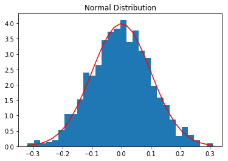

```python
mu, sigma = 0, 0.1 # mean and standard deviation
s = np.random.normal(mu, sigma, 1000)

import matplotlib.pyplot as plt
count, bins, ignored = plt.hist(s, 30, density=True)
plt.plot(bins, 1/(sigma * np.sqrt(2 * np.pi)) *np.exp( - (bins - mu)**2 / (2 * sigma**2) ), color='r')
plt.title('Normal Distribution')
plt.show()
```

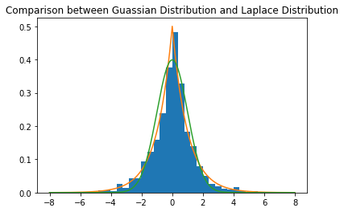

```python
import numpy as np
import matplotlib.pyplot as plt

loc, scale = 0., 1.
s = np.random.laplace(loc, scale, 1000)

count, bins, ignored = plt.hist(s, 30, density=True)
x = np.arange(-8., 8., .01)
pdf = np.exp(-abs(x-loc)/scale)/(2.*scale)
plt.plot(x, pdf)

g = (1/(scale * np.sqrt(2 * np.pi)) *
    np.exp(-(x - loc)**2 / (2 * scale**2)))
plt.title('Comparison between Guassian Distribution and Laplace Distribution')
plt.plot(x,g)
```

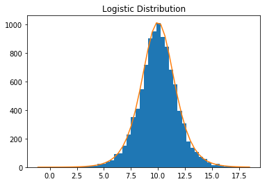

```python
import numpy as np
import matplotlib.pyplot as plt
import scipy as sy

loc,scale = 10, 1
s = np.random.logistic(loc,scale,10000)
count,bins,ignored = plt.hist(s, bins=50)

def logist(x, loc, scale):
    return sy.exp((loc-x)/scale)/(scale*(1+sy.exp((loc-x)/scale))**2)
plt.plot(bins, logist(bins, loc, scale)*count.max()/\
         logist(bins, loc,scale).max())
plt.title('Logistic Distribution')
plt.show()
```

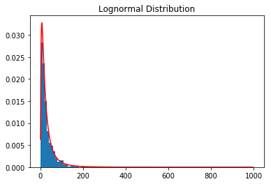

```python
mu, sigma = 3., 1. # mean and standard deviation
s = np.random.lognormal(mu, sigma, 1000)

import matplotlib.pyplot as plt
count, bins, ignored = plt.hist(s, 100, density=True, align='mid')
x = np.linspace(min(bins), max(bins), 10000)
pdf = (np.exp(-(np.log(x) - mu)**2 / (2 * sigma**2))
       / (x * sigma * np.sqrt(2 * np.pi)))

plt.plot(x, pdf, color='r')
plt.axis('tight')
plt.title('Lognormal Distribution')
plt.show()
```

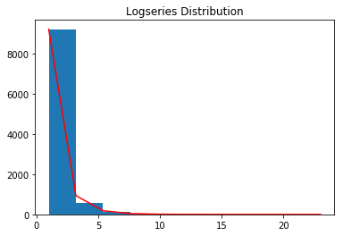

```python
import numpy as np
import matplotlib.pyplot as plt
import scipy as sy

a= .6
s = np.random.logseries(a, 10000)
count, bins, ignored = plt.hist(s)

def logseries(k, p):
    return -p**k/(k*sy.log(1-p))
plt.plot(bins, logseries(bins, a)*count.max()/
        logseries(bins, a).max(),'r')
plt.title('Logseries Distribution')
plt.show()
```

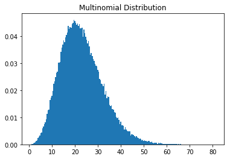

```python
import numpy as np
import matplotlib.pyplot as plt
import scipy as sy

values = plt.hist(np.random.noncentral_chisquare(3, 20, 100000),
    bins=200, density=True)

plt.title('Multinomial Distribution')
plt.show()
```

## 第四章 大数定律

$\begin{cases} 大数定律\\ 切比雪夫大数定律\\ 伯努利大数定律\\ 辛钦大数定律\\ 中心极限定理 \end{cases}$

个人感觉，大数定律是一个十分神奇的存在。第一次学习数理统计时就知晓她的重要性，然而，无论多少次魂牵梦萦，无论多少次努力靠近，我却始终不了解她。在实际应用场景中，我依然只会使用弱大数定律。而在课后习题中，我们也就使用一下切比雪夫不等式和马尔科夫不等式就完事了。也许是我接触到的场景都太偏应用了吧。

## $\S$4.1 大数定律

在数学与统计学中，大数定律又称大数法则、大数律，是描述相当多次数重复实验的结果的定律。根据这个定律知道，样本数量越多，则其平均就越趋近**期望值**。

大数定律很重要，因为它“保证”了一些随机事件的均值的长期稳定性。人们发现，在重复试验中，随着试验次数的增加，事件发生的**频率**趋于一个稳定值；人们同时也发现，在对物理量的测量实践中，测定值的**算术平均**也具有稳定性。比如，我们向上抛一枚硬币，硬币落下后哪一面朝上是偶然的，但当我们上抛硬币的次数足够多后，达到上万次甚至几十万几百万次以后，我们就会发现，硬币每一面向上的次数约占总次数的二分之一，亦即偶然之中包含着必然。**切比雪夫定理的一个特殊情况。辛钦定理和伯努利大数定律都概括了这一现象，都称为大数定律。**

## $\S$4.2 切比雪夫大数定律

设随机变量 $X_1$,$X_2$, ... ,$X_n$, ... 相互独立（是指对于任意 n>1, $X_1$,$X_2$, ... ,$X_n$, ...是相互独立），且具有相同的数学期望和方差：$$E(X_k)=\mu, D(X_k)=\sigma^2(k=1,2,...)$$

作前n个随机变量的算术平均: $\overline{X}=\frac{1}{n} \sum\limits_{k=1}^n X_k $ ,

则对于任意正数 $\epsilon$ ,有 $$ \lim\limits_{n \to \infty}P\lbrace |\overline{X}-\mu|<\epsilon \rbrace = \lim \limits_{n \to \infty}P\lbrace |\frac{1}{n}\sum\limits_{k=1}^n X_k-\mu|<\epsilon\rbrace =1 $$

证明：

由于 $$ E[\frac{1}{n} \lim\limits_{k=1}^n X_k]=\frac{1}{n}\sum\limits_{k=1}^n E(X_k)=\frac{1}{n}*n\mu, $$

$$D[\frac{1}{n} \lim\limits_{k=1}^n X_k]=\frac{1}{n^2}\sum\limits_{k=1}^n D(X_k)=\frac{1}{n^2}*n\sigma^2=\frac{\sigma^2}{n},$$

由契比雪夫不等式可得 $$P\lbrace {|\frac{1}{n}\sum\limits_{k=1}^n X_k-\mu|<\epsilon}\rbrace \geq 1-\frac{\sigma^2/n}{\epsilon^2}$$

在上式中令$n \to \infty$, 并注意到概率不能大于1，即得 $$\lim \limits_{n \to \infty}P\lbrace {|\frac{1}{n}\sum\limits_{k=1}^n X_k-\mu|<\epsilon} \rbrace =1.$$

**契比雪夫不等式**

设随机变量X具有数学期望E(X)=μ，方差D(X)=$\sigma^2$,对于任意ε>0，都有 $$P\lbrace |X-\mu|\geq \epsilon\rbrace \leq \frac{\sigma^2}{\epsilon^2} $$

方差越大，X落在区间外的概率越大，X的波动也就越大，与方差的意义统一了。等价公式 $$P\lbrace |X-\mu|< \epsilon\rbrace \geq 1- \frac{\sigma^2}{\epsilon^2} $$

## $\S$4.3 伯努利大数定律

设$n_A$是n次独立重复试验中事件A发生的次数。p是事件A在每次试验中发生的概率，则对于任意正数$\epsilon$>0,有 $$\lim\limits_{n \to \infty}P\lbrace|\frac{n_A}{n}-p|<\epsilon\rbrace=1 或 \lim\limits_{n \to \infty}P\lbrace|\frac{n_A}{n}-p|\geq\epsilon\rbrace=0$$

证明：

因为$n_A~b(n,p)$,有 $$ n_A=X_1+X_2+ ... +X_n,$$

其中，$X_1,X_2, ... ,X_n, ...$相互独立，且都服从以p为参数的（0-1）分布，因而

$$E(X_k)=p,D(X_k)=p(1-p)(k=1,2, ... ,n),$$ 由定理一得: $$\lim\limits_{n \to \infty}P\lbrace|\frac{1}{n}(X_1+X_2+ ... +X_n)-p|<\epsilon\rbrace=1,$$

即 $$\lim\limits_{n \to \infty}P\lbrace|\frac{n_A}{n}-p|<\epsilon\rbrace=1$$

这个定理表明事件发生的频率的稳定性.

## $\S$4.4 辛钦大数定律

设随机变量$X_1,X_2, ... ,X_n$, ...相互独立，服从同一分布，且具有数学期望 $E(X_k)=\mu(k=1,2, ...)$,则对于任意正数$\epsilon$,有 $$\lim\limits_{n \to \infty}P\lbrace |\frac{1}{n}\sum\limits_{k=1}^n X_k-\mu|<\epsilon \rbrace=1$$

显然，伯努利大数定理是辛钦定理的特殊情况。

**三个大数定律的比较**

| 定律 | 分布情况 | 期望 | 方差 | 结论 |
| --- | --- | --- | --- | --- |
| 辛钦大数定律 | 相互独立且同分布 | 存在 |  | 估算期望 |
| 契比雪夫不等式 | 相互独立 | 相同 | 相同 | 估算期望 |
| 伯努利大数定律 | 二项分布 | 相同 | 相同 | 频率=概率 |

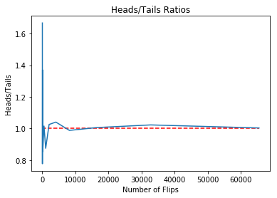

```python
#Python模拟抛硬币辅助说明大数定律
#由于random.random()生成的数可以看做是服从区间[0,1)上的均匀分布，所以以0.5为界限，随机生成的数中大于0.5或小于0.5的概率应该是相同的(相当于硬币是均匀的)。这样就用随机数模拟出了实际的抛硬币试验。理论上试验次数越多(即抛硬币的次数越多)，正反面出现的次数之比越接近于1(也就是说正反面各占一半).
import random
import matplotlib.pyplot as plt


def flip_plot(minExp, maxExp):
    """
    Assumes minExp and maxExp positive integers; minExp < maxExp
    Plots results of 2**minExp to 2**maxExp coin flips
    """
    # 两个参数的含义，抛硬币的次数为2的minExp次方到2的maxExp次方，也就是一共做了(2**maxExp - 2**minExp)批次实验，每批次重复抛硬币2**n次

    ratios = []
    xAxis = []
    for exp in range(minExp, maxExp + 1):
        xAxis.append(2**exp)
    for numFlips in xAxis:
        numHeads = 0 # 初始化，硬币正面朝上的计数为0
        for n in range(numFlips):
            if random.random() < 0.5:  # random.random()从[0, 1)随机的取出一个数
                numHeads += 1  # 当随机取出的数小于0.5时，正面朝上的计数加1
        numTails = numFlips - numHeads  # 得到本次试验中反面朝上的次数
        ratios.append(numHeads/float(numTails))  #正反面计数的比值
    plt.title('Heads/Tails Ratios')
    plt.xlabel('Number of Flips')
    plt.ylabel('Heads/Tails')
    plt.plot(xAxis, ratios)
    plt.hlines(1, 0, xAxis[-1], linestyles='dashed', colors='r')
    plt.show()

flip_plot(4, 16)
```

## $\S$4.5 中心极限定理

中心极限定理是概率论中的一组定理。中心极限定理说明，在适当的条件下，大量相互独立随机变量的均值经适当标准化后依分布收敛于正态分布。这组定理是数理统计学和误差分析的理论基础，指出了大量随机变量之和近似服从正态分布的条件。

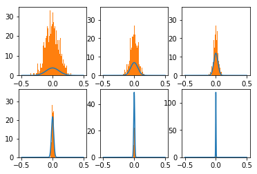

```python
import numpy as np
import matplotlib.pylab as plb
from scipy import stats
import math

number=[30,100,300,1000,5000,30000]
y=[]
for i in range(len(number)):
    ave_uniform=[]
    for j in range(1000):
        data=np.random.uniform(-1,1,number[i])
        variance=(1.0/3.0)/(1.0*number[i])
        summer=sum(data)
        ave_uniform.append(summer/(1.0*number[i]))
        Range=np.arange(-0.5,0.5,0.001)
    plb.subplot(230+i+1)
    plb.plot(Range,stats.norm.pdf(Range,0,math.sqrt(variance)))
    plb.hist(ave_uniform,bins=100)
plb.show()
```

**独立同分布的中心极限定理**

设随机变量$X_1,X_2, ... X_n, ...$相互独立，服从同一分布，且具有数学期望和方差：

$$E(X_k)=\mu,D(X_k)=\sigma^2(k=1,2, ...),$$

则随机变量之和$\sum\limits_{k=1}^nX_k$的标准化变量：

$$ Y_n=\frac{\sum\limits_{k=1}^n X_k-E(\sum\limits_{k=1}^n X_k)} {\sqrt{D(\sum\limits_{k=1}^n X_k)}} =\frac{\sum\limits_{k=1}^nX_k-n\mu} {\sqrt{n}\sigma} $$

分布函数$F_n(x)$对于任意x满足： $$\lim\limits_{n\to\infty}F_n(x)= \lim\limits_{n\to\infty}P\lbrace\frac {\sum\limits_{k=1}^nX_k-n\mu} {\sqrt{n}\sigma} \leq x\rbrace= \int_{-\infty}^x {\frac{1}{\sqrt{2\pi}}e^{-t^2/2}} {d}t =\Phi(x) $$

均值为μ，方差为$\sigma^2$>0的独立同分布的随机变量之和$\sum\limits_{k=1}^nX_k$的标准化变量，当n充分大时，有 $\frac {\sum\limits_{k=1}^nX_k-\mu} {\sigma/\sqrt{n}} $~N(0,1),将式子左端改写成 $$\frac {\sum\limits_{k=1}^nX_k-n\mu} {\sigma/\sqrt{n}} =\frac {\overline X-\mu} {\sigma/\sqrt{n}} $$

当n充分大时， $\frac {\overline X-\mu} {\sigma/\sqrt{n}} $~N(0,1)或$\overline X$~N($\mu,\sigma^2/n$).这也就是说，均值为μ，方差为$\sigma^2>0$的独立同分布的随机变量$X_1,X_2, ... ,X_n,$的算术平均$\overline X=\frac{1}{n}\sum\limits_{k=1}^nX_k$,当n充分大时近似地服从均值为μ，方差为$\frac{\sigma^2}{n}$的正态分布。

**用中心极限定理生成正态分布，其本质就是生成n个独立同分布的均匀分布**

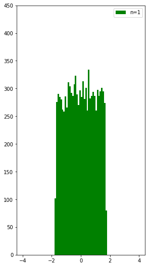

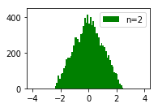

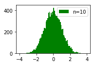

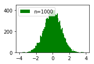

```python
import matplotlib.pyplot as plt
import numpy as np
def getNormal(SampleSize,n):
    result = []
    for i in range(SampleSize):
        # 利用中心极限定理，[0,1)均匀分布期望为0.5，方差为1/12
        iid = (np.mean(np.random.uniform(0,1,n))-0.5)*np.sqrt(12*n)
        result.append(iid)
    return result
# 生成10000个数，观察它们的分布情况
SampleSize = 10000
# 观察n选不同值时，对最终结果的影响
N = [1,2,10,1000]
plt.figure(figsize=(10,20))
subi = 220
for index,n in enumerate(N):
    subi += 1
    plt.subplot(subi)
    normal = getNormal(SampleSize, n)
    # 绘制直方图
    plt.hist(normal,np.linspace(-4,4,81),facecolor="green",label="n={0}".format(n))
    plt.ylim([0,450])
    plt.legend()
    plt.show()
```

可以看到，n=1时其实就是均匀分布，随着 n逐渐增大，直方图轮廓越来越接近正态分布了。

## 第五章 样本及抽样分布律

$\begin{cases} 常见统计量和性质\\ 使用numpy进行统计\\ 结合Scipy实现几种常见的统计分布 \end{cases}$

## $\S$5.1 常见统计量和性质

| 样本均值 | $\bar{x}=\frac{1}{n}\sum_{i=1}^{n}{x_{i}}$ |
| --- | --- |
| 样本方差 | $S^{2}=\frac{1}{n-1}\sum_{i=1}^{n}{(x_{i}-\bar{x})}^{2}$ |
| 样本标准差 | $S=\sqrt{\frac{1}{n-1}\sum_{i=1}^{n}{(x_{i}-\bar{x})}^2}$ |
| 样本k阶原点距 | $M_{k}=\frac{1}{n}\sum_{i=1}^{n}x_i^k,k=1,2...$ |
| 样本k阶中心距 | $M_{k}=\frac{1}{n}\sum_{i=1}^{n}{(x_{i}-\bar{x})}^k,k=2,3...$ |

其中，抽样样本均值的期望为总体的均值 $E(\bar{X})=\mu$, 均值方差为总体方差的1/n： $D(\bar{X})=\frac{\sigma^2}{n}$.

$E(S^2)=\sigma^2$, $E(S^{\ast2})=\frac{n-1}{n}\sigma^2$.

其中，$S^{\ast2}=\frac{1}{n}\sum_{i=1}^{n}{(x_{i}-\bar{x})}^2$, 为二阶中心距

## $\S$5.2 使用numpy进行统计

NumPy是Python语言的一个扩展程序库。支持高端大量的维度数组与矩阵运算，此外也针对数组运算提供大量的数学函数库。NumPy在统计上拥有大量函数可供调用。根据官方文档，现总结如下，并附上代码以供参考。

**顺序统计量**

| amin(a[, axis, out, keepdims]) | 返回数组或轴上的最小值 |
| --- | --- |
| amax(a[, axis, out, keepdims]) | 返回数组或轴上的最大值 |
| nanmin(a[, axis, out, keepdims]) | 返回数组或轴上的的最小值，忽略非数（NAN） |
| nanmax(a[, axis, out, keepdims]) | 返回数组或轴上的的最大值，忽略非数（NAN） |
| ptp(a[, axis, out]) | 轴上的数值范围（最大值-最小值） |
| percentile(a, q[, axis, out, ...]) | 计算小于某个值的观察值的百分比 |
| nanpercentile(a, q[, axis, out, ...]) | 计算小于某个值的观察值的百分比，忽略非数 |

**平均值和方差**

| median(a[, axis, out, overwrite_input, keepdims]) | 沿轴计算中值 |
| --- | --- |
| average(a[, axis, weights, returned]) | 沿轴计算加权平均值 |
| mean(a[, axis, dtype, out, keepdims]) | 沿轴计算算术平均值 |
| std(a[, axis, dtype, out, ddof, keepdims]) | 沿轴计算标准差 |
| var(a[, axis, dtype, out, ddof, keepdims]) | 沿轴计算方差 |
| nanmedian(a[, axis, out, overwrite_input, ...]) | 沿轴计算中值，忽略NAN值 |
| nanmean(a[, axis, dtype, out, keepdims]) | 沿轴计算算术平均值，忽略NAN值 |
| nanstd(a[, axis, dtype, out, ddof, keepdims]) | 沿轴计算标准差，忽略NAN值 |
| nanvar(a[, axis, dtype, out, ddof, keepdims]) | 沿轴计算方差，忽略NAN值 |

**相关性**

| corrcoef(x[, y, rowvar, bias, ddof]) | 返回Pearson相关系数 |
| --- | --- |
| correlate(a, v[, mode]) | 返回两个序列的交叉相关性 |
| cov(m[, y, rowvar, bias, ddof, fweights, ...]) | 给定数据和权重，估计协方差 |

## $\S$5.3 结合Scipy实现几种常见的统计分布

**t分布**

设$x_{1},x_{2},...,x_{n}$为来自正态总体$N(\mu,\sigma^2)$的一个样本，则样本函数$$t=\frac{\bar{x}-\mu}{s/\sqrt{n}}\sim t(n-1)$$其中t(n-1)表示自由度为n-1的t分布，当n足够大时t分布近似于N（0,1）分布

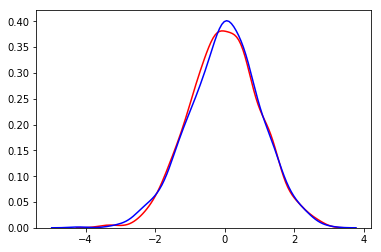

```python
#模拟t分布，蓝色是标准正态分布,红色是t分布
from  scipy import stats
from scipy.stats import expon
from scipy.stats import norm
import pylab as pl
from scipy.stats import t
import numpy as np
import seaborn as sns

nm = norm.rvs(size=1000)
d = t.rvs(n, size=1000)
sns.distplot(d, color='red', hist=False, kde_kws={"shade": False})
sns.distplot(nm, color='blue', hist=False, kde_kws={"shade": False})

pl.show()
```

**$\chi^2$分布**

设$x_{1},x_{2},...,x_{n}$为来自正态总体$N(\mu,\sigma^2)$的一个样本，则样本函数$$\omega=\frac{(n-1)S^2}{\sigma^2}\sim \chi^2(n-1)$$其中$\chi^2(n-1)$表示自由度为n-1的$\chi^2$分布。χ2检验是以χ2分布为基础的一种假设检验方法，主要用于分类变量。其基本思想是根据样本数据推断总体的分布与期望分布是否有显著性差异，或者推断两个分类变量是否相关或者独立。 一般可以设原假设为 H0：观察频数与期望频数没有差异，或者两个变量相互独立不相关。实际应用中，我们先假设H0成立，计算出χ2的值，χ2表示观察值与理论值之间的偏离程度。根据χ2分布，χ2统计量以及自由度，可以确定在H0成立的情况下获得当前统计量以及更极端情况的概率p。如果p很小，说明观察值与理论值的偏离程度大，应该拒绝原假设。否则不能拒绝原假设。A为实际值，T为理论值。 $$\chi^2=\sum{(A-T)^2}{T}$$

```python
#使用卡方检验：“豌豆黄圆：黄皱：绿圆:绿皱=315：101：108：32 是否符合9:3:3:1的理论比例”
import scipy.stats as stats
import pandas as pd
import numpy as np

observe=[315,101,108,32]
proportion=[9,3,3,1]
expect=[sum(observe)*i/sum(proportion) for i in proportion]
chisquare_val,p_val=stats.chisquare(observe,expect)
if p_val>0.05:
    result='Yes'
else:
    result='No'
result_table=pd.DataFrame({'chisquare_value':[chisquare_val],
    'p_value':[p_val],'result':[result]})
result_table
```

|  | chisquare_value | p_value | result |
| --- | --- | --- | --- |
| 0 | 0.470024 | 0.925426 | Yes |

**F分布**

设$x_{1},x_{2},...,x_{n}$为来自正态总体$N(\mu,\sigma^2)$的一个样本，而$y_1,y_2,...y_n$为来自正态总体$N(\mu,\sigma^2)$的一个样本，则样本函数 $$F=\frac{S_1^2/\sigma_1^2}{S_2^2/\sigma_2^2}\sim F(n_1-1,n_2-2)$$ 其中，$S_1^2=\frac{1}{n_1-1}\sum_{i=1}^{n_1}(x_i-\bar{x})^2$， $S_2^2=\frac{1}{n_2-1}\sum_{i=1}^{n_2}(y_i-\bar{y})^2$，$F(N_1-1,n_2-1)$表示第一自由度为$n_1-1$，第二自由度为$n_2-1$的F分布

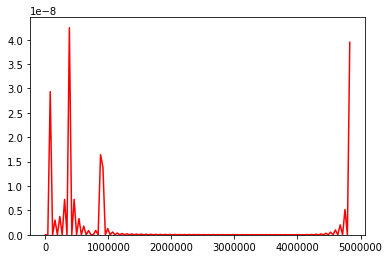

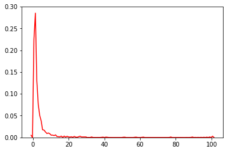

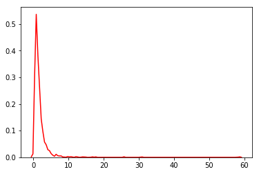

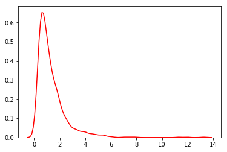

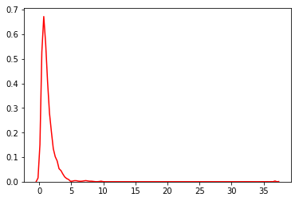

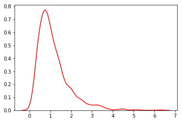

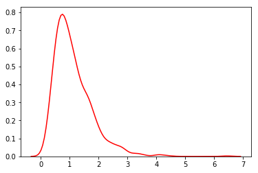

```python
from  scipy import stats
from scipy.stats import expon
from scipy.stats import norm
import pylab as pl
from scipy.stats import t
from scipy.stats import f
import numpy as np
import seaborn as sns

lst = [
    1, 3, 5, 7, 10, 15, 20
]
for i in lst:
    rv = f(10, i)
    d = rv.rvs(size=1000)
    sns.distplot(d, color='red', hist=False, kde_kws={"shade": False})
    pl.show()
```

到这里为止，是非常基础的概率论与数理统计方面的知识点整理。推荐阅读后面的**《Python语言与科学计算》**